# Rmarkdown demo

Jay Hesselberth

2015-03-02

# Summary

## Common libraries

```r
library(dplyr)
library(ggplot2)
library(knitr)
```

## Loading data

```r
# assumes workshop repo is in $HOME/devel
setwd("~/devel/workshop/content/Miscellaneous/data")

# load bed data
bed.df <- read.delim('lamina.bed', header=TRUE)
# fixup chrom name
names(bed.df)[1] <- 'chrom'

# load expr data
expr.df <- read.delim('expr-geno-covs.txt', header=TRUE)

# load peaks data
peaks.df <- read.delim('peaks.chr22.bed.gz',
                       col.names = c('chrom','start','end','name'))
```

## Summarizing data

First, we can dynamically generate some simple statistics. For example, there are 24 chromosomes in the BED file we loaded.

You can also generate view of the data with:

```r
summary(bed.df)
```

```
##      chrom         start                end                value
##  chr3   :106   Min.   :    11619   Min.   :   194068   Min.   :0.7008
##  chr1   :101   1st Qu.: 32975711   1st Qu.: 34467096   1st Qu.:0.8556
##  chr2   :100   Median : 71422684   Median : 72288477   Median :0.9117
##  chr4   : 94   Mean   : 79469493   Mean   : 80449563   Mean   :0.8960
##  chr5   : 93   3rd Qu.:113461063   3rd Qu.:114204434   3rd Qu.:0.9488
##  chr6   : 79   Max.   :245647839   Max.   :247066405   Max.   :1.0000
##  (Other):771
```

```r
table(expr.df$condition)
```

```
##
##    case control
##      89      87
```

```r
# part of the `knitr` package
kable(head(expr.df))
```

| condition | genotype | age | gender | smoking | expression | sample_id |
| --- | --- | --- | --- | --- | --- | --- |
| case | CC | 65 | Male | former | 1119 | sample1 |
| case | CC | 56 | Male | former | 683 | sample2 |
| control | CC | 29 | Male | nonsmoker | 252 | sample3 |
| control | CC | 22 | Male | nonsmoker | 232 | sample4 |
| case | CC | 58 | Male | 0 | 362 | sample5 |
| control | CC | 17 | Female | nonsmoker | 20 | sample6 |

## Plots

Let’s have a look at the distribution of CpG sizes on each chromosome in the `lamina.bed` file:

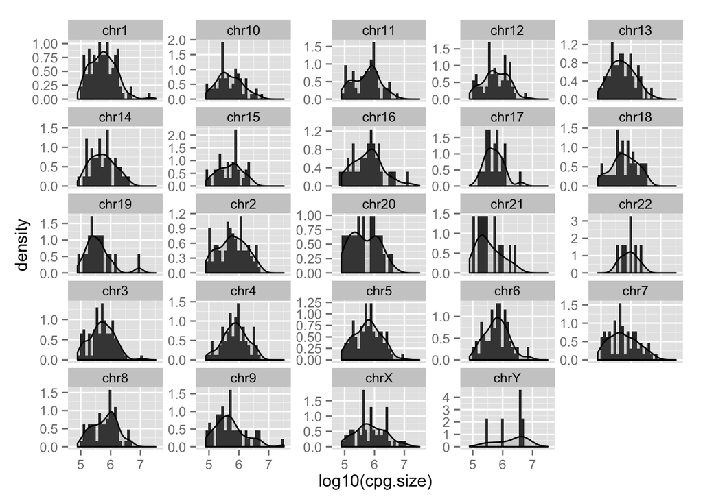

```r
bed.df %>%
  mutate(cpg.size = end - start) %>%
  ggplot(aes(x = log10(cpg.size), y = ..density..)) +
  geom_histogram() +
  geom_density(alpha = 0.2, fill = 'grey50') +
  facet_wrap(~chrom, scales = 'free_y')
```

Can also use the new ggvis for this, but doesn’t support faceting yet. Also Rmarkdown doesn’t support emoji :(((. `ggvis` also breaks PDF output (HTML only).

```r
library(ggvis)
bed.df %>%
  mutate(cpg.size = end - start) %>%
  ggvis(~factor(chrom), ~log10(cpg.size)) %>%
  layer_boxplots() %>%
  add_axis("x", title='', properties = axis_props(labels = list(angle = -90)))
```

[output not shown]

## Data mainuplation

```r
# first few enntries of each transcription factor
peaks.df %>% group_by(name) %>% slice(1:2)
```

```
## Source: local data frame [320 x 4]
## Groups: name
##
##    chrom    start      end   name
## 1  chr22 17081859 17082219 ARID3A
## 2  chr22 17262369 17262729 ARID3A
## 3  chr22 17082094 17082350   ATF1
## 4  chr22 17139135 17139391   ATF1
## 5  chr22 17568451 17568971   ATF2
## 6  chr22 17602108 17602688   ATF2
## 7  chr22 17082144 17082294   ATF3
## 8  chr22 17262414 17262650   ATF3
## 9  chr22 17067131 17067451  BACH1
## 10 chr22 17262259 17262579  BACH1
## ..   ...      ...      ...    ...
```

## Fancier manipluation

Aggregation functions in dplyr return 1 value for each of n inputs, e.g. the mean of peak widths for each factor

Windowing functions return n values for n inputs and enable more expressive analysis.

http://cran.rstudio.com/web/packages/dplyr/vignettes/window-functions.html

For each factor, find its largest peaks using `min_rank()`:

```r
peaks.df %>%
  group_by(name) %>%
  mutate(peak.width = end - start) %>%
  filter(min_rank(desc(peak.width)) == 1) %>%
  arrange(desc(peak.width)) %>%
  head(10) %>%
  kable()
```

| chrom | start | end | name | peak.width |
| --- | --- | --- | --- | --- |
| chr22 | 39101281 | 39102068 | ARID3A | 787 |
| chr22 | 17082094 | 17082350 | ATF1 | 256 |
| chr22 | 17139135 | 17139391 | ATF1 | 256 |
| chr22 | 17255527 | 17255783 | ATF1 | 256 |
| chr22 | 17579474 | 17579730 | ATF1 | 256 |
| chr22 | 17955944 | 17956200 | ATF1 | 256 |
| chr22 | 17956542 | 17956798 | ATF1 | 256 |
| chr22 | 18111518 | 18111774 | ATF1 | 256 |
| chr22 | 18121368 | 18121624 | ATF1 | 256 |
| chr22 | 18155901 | 18156157 | ATF1 | 256 |

```r
peaks.df %>%
  group_by(name) %>%
  mutate(peak.width = end - start) %>%
  filter(cume_dist(peak.width) < 0.1) %>%
  summarize(count = n()) %>%
  arrange(desc(count)) %>%
  head(10) %>%
  kable()
```

| name | count |
| --- | --- |
| CTCF | 307 |
| POLR2A | 285 |
| MAX | 208 |
| EP300 | 160 |
| FOS | 138 |
| ELF1 | 123 |
| EBF1 | 119 |
| EGR1 | 118 |
| RAD21 | 118 |
| RUNX3 | 118 |

Find TFs that tend to have neighboring peaks using `lead()` or `lag()`. The `order_by` argument specifies the variable to order the rows by (default is `row_number`:

```r
peaks.df %>%
  group_by(name) %>%
  filter(name == lead(name, order_by = start)) %>%
  summarize(count = n()) %>%
  arrange(desc(count)) %>%
  head(10) %>%
  kable()
```

| name | count |
| --- | --- |
| CTCF | 3324 |
| POLR2A | 3032 |
| EP300 | 2160 |
| RAD21 | 2106 |
| MAX | 2087 |
| CEBPB | 1988 |
| MYC | 1844 |
| FOS | 1694 |
| JUND | 1674 |
| YY1 | 1460 |

Cumulative density of peak widths for each factor.

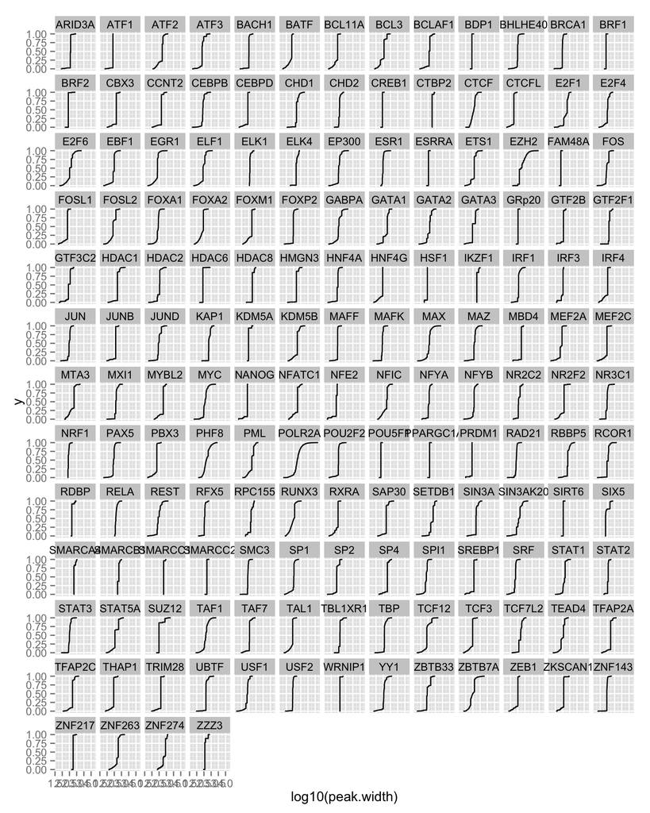

```r
peaks.df %>%
  arrange(name, start) %>%
  group_by(name) %>%
  mutate(peak.width = end - start) %>%
  ggplot(aes(log10(peak.width))) + stat_ecdf() + facet_wrap(~name)
```

### Questions

- How would you modify the above code chunks to figure out what proportion of peaks these represent?